# difuso

Fernando Menendez

October 20, 2018

# Aproximacion del problema mediante clustering difuso

## Introduccion

Dado el dataset de estrellas de Hiparcos y el set de Hyades identificadas previamente se procede a realizar experimentos de clustering difuso mediante la funcion *fanny* del paquete *cluster*. En los mismos se hara enfasis en los siguientes puntos:

*Seleccion de Variables del dataset origen* Hiperparametrizacion de *k* y *memb.exp* *Revision de la presencia de Hyades en los clusters

Para este ultimo punto se intentará identificar cluster relativamente pequeños que contengan la mayor cantidad de las Hyades previamente señaladas como tales.

## Constuccion de los experimentos

Los experimentos con el algoritmo se construyen a partir de los siguientes pasos:

1. Ejecucion y extraccion de resultados identificando para cada cluster de cada ejecucion la cantidad de Hyades (definidas)
2. ilustracion de maxima cantidad de hyades en un cluster por ejecucion, tamaño del cluster y tamaño del cluster en relacion a la cantidad de hyades presentes (ratio)
3. Conclusion y extraccion de candidatas cuando corresponda.

## Definiciones

*Se definio como rango de experimentacion de *k* entre **2** y **10** ya que en las ejecuciones de los otros algoritmos se relativizó la mayor tasa de clasificacion en valores de *k* pequeños (entre 2 y 3), con el fin de no sesgar el potencial del metodo se extiende el rango hasta 10 clusters

*Arbitrariamente, se selecciono el rango de *memb.exp* entre **1.1** y **2**, dejando fuera el valor 1 ya que en ese caso el algoritmo se comporta como k-means que ya fue abordado previamente.

*A fin de identificar la pertenencia a los clusters segun los resultados de la funcion de membresia se establece como representativo un valor **mayor** a **0.5**.

*Se establecieron 2 grandes experimentos con seleccion de variables basados en los resultados precios de la ejecucion de cluster por densidad, siendo:

1. Todas las variables de Hiparcos
2. Todas las variables, con excepcion de las medidas de posicion

*Para cada salida de la hyperparametrizacion, se identifica visualmente si alguno de los test es aceptable para producir candidatos

```r
hip<-read.csv("..\\02.Preprocesamiento\\hip_version1.csv")
summarizeColumns(hip)
```

```
##            name    type na          mean         disp        median
## 1           HIP numeric  0  2.121964e+04 4.322034e+03  2.109250e+04
## 2      RA_J2000 numeric  0  4.876836e-01 2.836723e-01  4.936358e-01
## 3      DE_J2000 numeric  0  5.031920e-01 2.921657e-01  5.034610e-01
## 4           Plx numeric  0 -5.296291e-17 1.000000e+00 -2.766067e-01
## 5          pmRA numeric  0  2.116658e-17 1.000000e+00 -2.368588e-01
## 6          pmDE numeric  0 -2.282410e-18 1.000000e+00  2.231431e-01
## 7          Vmag numeric  0 -5.573271e-16 1.000000e+00  5.388526e-02
## 8           B.V numeric  0  2.108072e-17 1.000000e+00 -1.720137e-01
## 9 Symbad_Hyades logical  0            NA 1.893939e-02            NA
##            mad           min          max nlevs
## 1 5368.4946000 13510.0000000 28887.000000     0
## 2    0.3600514     0.0000000     1.000000     0
## 3    0.3777898     0.0000000     1.000000     0
## 4    0.4133056    -0.8723429    16.265614     0
## 5    0.2557236    -4.7244992    26.449728     0
## 6    0.2262000   -21.2811893     3.696902     0
## 7    0.8845585    -5.2524243     2.887028     0
## 8    0.9814142    -1.8610277     5.343554     0
## 9           NA    50.0000000  2590.000000     2
```

### Normalizacion de variables y cálculo de matrices de distancias}

```r
hip.scaled<-hip %>% mutate_at(.funs = funs(scale(.,center = T, scale = T)), .vars = vars(-HIP,-Symbad_Hyades)) %>%
  select(-HIP,-Symbad_Hyades)
hip.eucl<-daisy(as.matrix(hip.scaled), metric = "euclidean")
```

## Experimento 1: Todas las Variables con distancia Euclidea

```r
fzzy_eucl<-run_fuzzy(hip.eucl,2:10)
```

```r
fzzy_eucl$coef$test<-as.factor(fzzy_eucl$coef$test)
fzzy_eucl.rt<-fzzy_eucl$clustering %>%
  mutate(total=Hyades + No_Hyades,ratio=round(Hyades/total,2)) %>%
  group_by(test) %>% filter(Hyades==max(Hyades)) %>% ungroup() %>%
  inner_join(fzzy_eucl$coef, by="test") #%>% filter(dunn_coeff>.7)
sorted.test<-order(levels(as.factor(fzzy_eucl.rt$test)))
fzzy_eucl.rt$test=factor(fzzy_eucl.rt$test,levels = sorted.test)
fzzy_eucl.rt
```

```
## # A tibble: 22 x 10
##    Cluster Hyades No_Hyades   k_n memb.exp test  total ratio dunn_coeff
##    <chr>    <dbl>     <dbl> <int>    <dbl> <fct> <dbl> <dbl>      <dbl>
##  1 1           27      1387     2      1.1 1      1414  0.02       0.85
##  2 2           26      1213     2      1.2 2      1239  0.02       0.69
##  3 2           24      1202     2      1.3 3      1226  0.02       0.56
##  4 2           46       886     3      1.1 11      932  0.05       0.81
##  5 2           40       764     3      1.2 12      804  0.05       0.6
##  6 2           11       291     3      1.3 13      302  0.04       0.42
##  7 3           49       325     4      1.1 21      374  0.13       0.84
##  8 3           34       534     4      1.2 22      568  0.06       0.59
##  9 4           49       323     5      1.1 31      372  0.13       0.85
## 10 4           49       246     5      1.2 32      295  0.17       0.62
## # ... with 12 more rows, and 1 more variable: normalized <dbl>
```

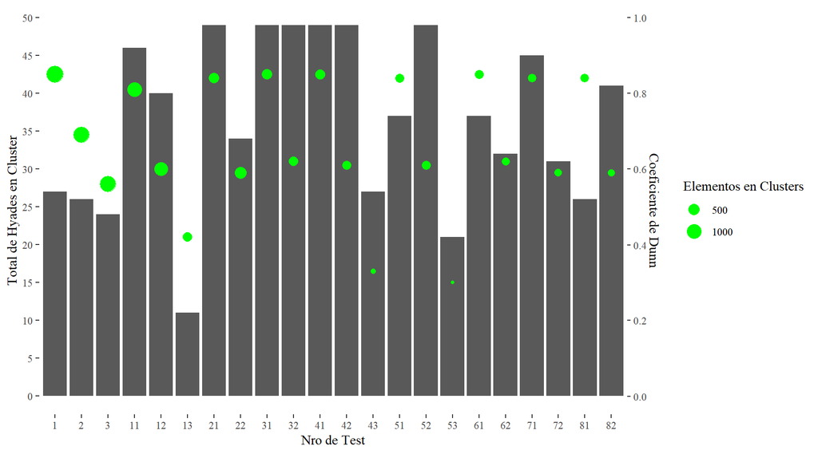

```r
ggplot(data = fzzy_eucl.rt, aes(x=test)) +
  geom_bar(aes(y=Hyades),stat="identity") +
  geom_point(aes(y=dunn_coeff/2*100,size=total),color="green", stat = "identity") +
  scale_y_continuous(name="Total de Hyades en Cluster",breaks = seq(0,50,5),
                     sec.axis = sec_axis(~.*2/100,breaks = seq(0,1,.20), name = "Coeficiente de Dunn")) +
#  ylab("Total de Hyades en Cluster") +
  xlab("Nro de Test") +
  labs(size="Elementos en Clusters") +
  scale_fill_continuous(breaks = seq(250,1000,250)) +
#  scale_x_continuous(breaks=seq(1,150,1)) +
  theme_tufte()
```

```r
fzzy_eucl.rt %>% filter(test %in% c(21,31,41))
```

```
## # A tibble: 3 x 10
##   Cluster Hyades No_Hyades   k_n memb.exp test  total ratio dunn_coeff
##   <chr>    <dbl>     <dbl> <int>    <dbl> <fct> <dbl> <dbl>      <dbl>
## 1 3           49       325     4      1.1 21      374  0.13       0.84
## 2 4           49       323     5      1.1 31      372  0.13       0.85
## 3 3           49       311     6      1.1 41      360  0.14       0.85
## # ... with 1 more variable: normalized <dbl>
```

```r
fuzz1<-run_fuzzy_one(hip.eucl,5,1.1)
cand1<-fuzz1 %>% filter(Cluster==4,Hyades==FALSE)
fuzz2<-run_fuzzy_one(hip.eucl,6,1.1)
cand2<-fuzz2 %>% filter(Cluster==3,Hyades==FALSE)
fuzz3<-run_fuzzy_one(hip.eucl,4,1.1)
cand3<-fuzz3 %>% filter(Cluster==3,Hyades==FALSE)
cand.eucl<-inner_join(cand1,cand2, by = "HIP") %>% inner_join(cand3,by="HIP") %>% select(HIP)
```

## Experimento 2: Sin medidas de posicion con distancia Euclidea

### Se extraen las medidas de posicion, se normalizan las variables y se recalculan las matrices de distancia

```r
hip.scaled2<-hip %>% mutate_at(.funs = funs(scale(.,center = T, scale = T)), .vars = vars(-HIP,-Symbad_Hyades)) %>%
  select(-HIP,-Symbad_Hyades,-RA_J2000,-DE_J2000)
hip.eucl2<-daisy(as.matrix(hip.scaled2), metric = "euclidean")
```

```r
nopos_eucl<-run_fuzzy(hip.eucl2,2:10)
```

```r
nopos_eucl$coef$test<-as.factor(nopos_eucl$coef$test)
nopos_eucl.rt<-nopos_eucl$clustering %>%
  mutate(total=Hyades + No_Hyades,ratio=round(Hyades/total,2)) %>%
  group_by(test) %>% filter(Hyades==max(Hyades)) %>% ungroup() %>%   inner_join(nopos_eucl$coef, by="test")
sorted.test<-order(levels(as.factor(nopos_eucl.rt$test)))
nopos_eucl.rt$test=factor(nopos_eucl.rt$test,levels = sorted.test)
nopos_eucl.rt
```

```
## # A tibble: 41 x 10
##    Cluster Hyades No_Hyades   k_n memb.exp test  total ratio dunn_coeff
##    <chr>    <dbl>     <dbl> <int>    <dbl> <fct> <dbl> <dbl>      <dbl>
##  1 2           50      1037     2      1.1 1      1087  0.05      0.93
##  2 2           49      1011     2      1.2 2      1060  0.05      0.83
##  3 2           49      1019     2      1.3 3      1068  0.05      0.74
##  4 2           48      1042     2      1.4 4      1090  0.04      0.65
##  5 2           47      1073     2      1.5 5      1120  0.04      0.580
##  6 1           47      1088     2      1.6 6      1135  0.04      0.53
##  7 3           50       430     3      1.1 11      480  0.1       0.95
##  8 2           38       780     3      1.2 12      818  0.05      0.79
##  9 2           33       751     3      1.3 13      784  0.04      0.69
## 10 2           18       716     3      1.4 14      734  0.02      0.580
## # ... with 31 more rows, and 1 more variable: normalized <dbl>
```

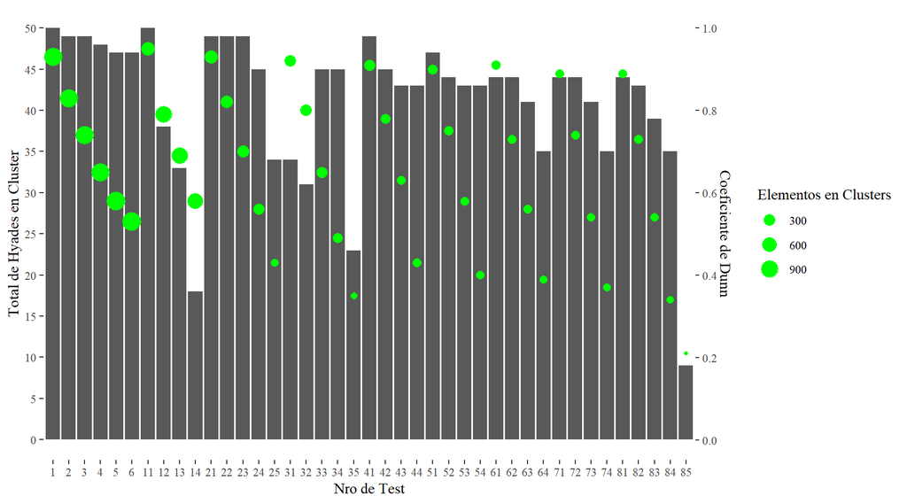

```r
ggplot(data = nopos_eucl.rt, aes(x=test)) +
  geom_bar(aes(y=Hyades),stat="identity") +
  geom_point(aes(y=dunn_coeff/2*100,size=total),color="green", stat = "identity") +
  scale_y_continuous(name="Total de Hyades en Cluster",breaks = seq(0,50,5),
                     sec.axis = sec_axis(~.*2/100,breaks = seq(0,1,.20), name = "Coeficiente de Dunn")) +
#  ylab("Total de Hyades en Cluster") +
  xlab("Nro de Test") +
  labs(size="Elementos en Clusters") +
  scale_fill_continuous(breaks = seq(250,1000,250)) +
#  scale_x_continuous(breaks=seq(1,150,1)) +
  theme_tufte()
```

**OBS:** Los experimentos 1, 11, 21 y 41 muestran resultados similares, variando solo en ellos la cantidad de clusters, revisamos 11, 21 y 41 ya que muestran clusters mas pequeños

```r
nopos_eucl.rt %>% filter(test %in% c(1,11,21,41))
```

```
## # A tibble: 4 x 10
##   Cluster Hyades No_Hyades   k_n memb.exp test  total ratio dunn_coeff
##   <chr>    <dbl>     <dbl> <int>    <dbl> <fct> <dbl> <dbl>      <dbl>
## 1 2           50      1037     2      1.1 1      1087  0.05       0.93
## 2 3           50       430     3      1.1 11      480  0.1        0.95
## 3 4           49       381     4      1.1 21      430  0.11       0.93
## 4 5           49       228     6      1.1 41      277  0.18       0.91
## # ... with 1 more variable: normalized <dbl>
```

```r
fuzz1<-run_fuzzy_one(hip.eucl2,3,1.1)
cand1<-fuzz1 %>% filter(Cluster==3,Hyades==FALSE)
fuzz2<-run_fuzzy_one(hip.eucl2,4,1.1)
cand2<-fuzz2 %>% filter(Cluster==4,Hyades==FALSE)
fuzz3<-run_fuzzy_one(hip.eucl2,6,1.1)
cand3<-fuzz3 %>% filter(Cluster==5,Hyades==FALSE)
cand.eucl2<-inner_join(cand1,cand2, by = "HIP") %>% inner_join(cand3,by="HIP") %>% select(HIP)
```

## Revision de Candidatas

Se cruzan las estrellas candidatas de los experimentos resaltados anteriormente

```r
cand.list.eucl <- cand.eucl %>%
  inner_join(cand.eucl2, by = "HIP")
cand.list.eucl
```

```
## # A tibble: 143 x 1
##      HIP
##    <dbl>
##  1 13589
##  2 13600
##  3 13601
##  4 13679
##  5 13982
##  6 14054
##  7 14098
##  8 14230
##  9 14258
## 10 14721
## # ... with 133 more rows
```

```r
cand.dbscan$source<-"DBSCAN"
cand.list.eucl$source<-"FUZZY"
```

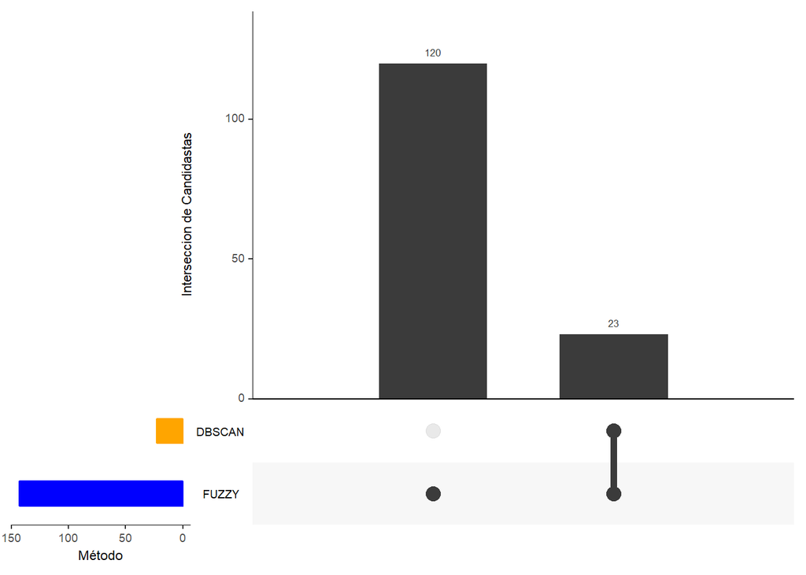

```r
listInput<-list(DBSCAN=cand.dbscan$HIP,FUZZY=cand.list.eucl$HIP)
upset(fromList(listInput), order.by = "freq",point.size = 4, line.size = 2,
    mainbar.y.label = "Interseccion de Candidastas", sets.x.label = "Método",
    sets.bar.color=c("blue","orange"))
```

**OBS:** Como podemos ver en el grafico anterior, la primera columna muestras el numero de estrellas candidatas que solo pertenecen a la lista de FUZZY y la segunda muestra las que estan tanto en FUZZY como DBSCAN, como en este caso **todas las estrellas detectadas por la ejecucion de DBSCAN estan incluidas en la salida de del Clustering difuso** , no hay una tercera barra con estrellas solo presentes en DBSCAN